# Milestone Report

Courtney Rowlands

10/30/2019

## Milestone Project

The goal of this project is to display that you’ve gotten used to working with the data and that you are on track to create your prediction algorithm. Please submit a report on R Pubs (http://www.rpubs.com/) that explains your exploratory analysis and your goals for the eventual app and algorithm. This document should be concise and briefly summarize your plans for creating the prediction algorithm and Shiny app in a way that would be understandable to a non-data scientist manager. You should make use of table and plots to illustrate important summaries of the data set.

**The motivation for this project is to:**  
1. Demonstrate that you’ve downloaded the data and have successfully loaded it.  
2. Created a basic report of summary statistics about the data sets.  
3. Report any interesting findings that you amassed so far.  
4. Get feedback on your plans for creating a prediction algorithm and Shiny app.

### Download, Extract, & Read Data

This section has been commented out because the files have already been downloaded and unzipped locally.

```r
## Download and extract zip file
## if (!file.exists("data")) {
##  dir.create("data")
## }

## fileUrl <- "https://d396qusza40orc.cloudfront.net/dsscapstone/dataset/Coursera-SwiftKey.zip"
## download.file(fileUrl,destfile="./data/Coursera-SwiftKey.zip")

## unzip(zipfile="./data/Coursera-SwiftKey.zip",exdir="./data")
```

```r
## Read blogs data
blogs <- file("data/final/en_US/en_US.blogs.txt")
blogs <- readLines(blogs,encoding="UTF-8",skipNul=TRUE)

## Read news data
news <- file("data/final/en_US/en_US.news.txt")
news <- readLines(news,encoding="UTF-8",skipNul=TRUE)
## Read the tweeters
twitter <- file("data/final/en_US/en_US.twitter.txt")
twitter <- readLines(twitter,encoding="UTF-8",skipNul=TRUE)
```

### Data Report

```r
summary(blogs)
```

```
##    Length     Class      Mode
##    899288 character character
```

```r
summary(news)
```

```
##    Length     Class      Mode
##     77259 character character
```

```r
summary(twitter)
```

```
##    Length     Class      Mode
##   2360148 character character
```

```r
wordCountBlogs <- length(blogs)
wordCountNews <- length(news)
wordCountTwitter<- length(twitter)

blogsSize <- file.info("data/final/en_US/en_US.blogs.txt")$size
newsSize <- file.info("data/final/en_US/en_US.news.txt")$size
twitterSize <- file.info("data/final/en_US/en_US.twitter.txt")$size
```

### Create Data Sample

Because the dataset is so large, I am creating a sample of the dataset.

```r
set.seed(123)
sampleBlogs <- sample(blogs,size=length(blogs)*0.01)
sampleNews <- sample(news,size=length(news)*0.01)
sampleTwitter <- sample(twitter,size=length(twitter)*0.01)
dataSample <- sample(paste(sampleBlogs,sampleNews,sampleTwitter),size=5000,replace=TRUE)

head(na.omit(dataSample),5)
```

```
## [1] "My legs are sore. I didn't even make it to the top. Maybe one day. I'm so excercising more this summer. That failed. He began to lose weight, felt a constant urge to pee and would frequently have trouble catching his breath. Eventually, he found himself at St. Vincent Charity Medical Center.…
## [2] "Starting this month, the Osaka Municipal Government is conducting the survey covering some 38,000 employees. The move was prompted by an incident in February, in which a city employee showed their tattoo to children at a welfare facility. Osaka Mayor Toru Hashimoto ordered the survey be cond…
## [3] "Scenario play in Warmahordes is not just a tournament standard. In fact, I would advice anyone already over the game rules learning hill with a decent (25 points?) collection to play scenarios from the get go. Here’s why. \"This case is about trust and personal responsibility.\" said Eric Ka…
## [4] "Iused a damp cloth to wipe off the wood. And that was it. We were totally done. Oh, right except for that part about attaching the mirror which I still haven’t done. But before we could drag it inside, we needed to figure out where to put it. I canvassed our house and decided that it would f…
## [5] "My radio crackles, and then Sam’s voice comes over the radio, “Sam here, that would be the scouts returning, Randy and Sutton.” Don Rose, a political consultant who was an anti-Vietnam War spokesman during the troubled 1968 Democratic National Convention that led to riots, also spoke. He sai…
```

### Clean Data using corpus tm_map.

The main structure for managing documents in tm is a so-called Corpus, representing a collection of text documents. A corpus is an abstract concept, and there can exist several implementations in parallel.  
The full documentation can be found here: https://cran.r-project.org/web/packages/tm/vignettes/tm.pdf  
Here, I am using the tm package to transform case for consistency, and to remove punctuation, numbers, and other junk data.

```r
dataSample <- iconv(dataSample, 'UTF-8', 'ASCII')
corpus <- Corpus(VectorSource(as.data.frame(dataSample, stringsAsFactors = FALSE)))
corpus <- tm_map(corpus,content_transformer(tolower))
corpus <- tm_map(corpus,PlainTextDocument)
corpus <- tm_map(corpus,removePunctuation)
corpus <- tm_map(corpus,removeNumbers)
corpus <- tm_map(corpus,removeWords, stopwords("english"))
corpus <- tm_map(corpus,stemDocument)
corpus <- tm_map(corpus,stripWhitespace)
```

### Document Term Matrix

A common approach in text mining is to create a term-document matrix from a corpus. In the tm package the classes TermDocumentMatrix and DocumentTermMatrix (depending on whether you want terms as rows and documents as columns, or vice versa) employ sparse matrices for corpora. Inspecting a term-document matrix displays a sample, whereas as.matrix() yields the full matrix in dense format (which can be very memory consuming for large matrices).  
The full documentation can be found here: https://cran.r-project.org/web/packages/tm/vignettes/tm.pdf

```r
tdmWords <- DocumentTermMatrix(corpus)
print(tdmWords)
```

```
## <<DocumentTermMatrix (documents: 2, terms: 12031)>>
## Non-/sparse entries: 12031/12031
## Sparsity           : 50%
## Maximal term length: 62
## Weighting          : term frequency (tf)
```

### Data Visualization

Data visualization is just an easier way for a non-tech person to view the data. I’ve utilized the ggplot2 and wordcloud libraries for my visualization.

```r
wordFrequency <- sort(colSums(as.matrix(tdmWords)),decreasing=TRUE)
dfWordFrequency <- as.data.frame(wordFrequency[1:30])
dfWordFrequency <- data.frame(Words=row.names(dfWordFrequency),dfWordFrequency)
names(dfWordFrequency)[2] = "Frequency"
head(dfWordFrequency)
```

```
##      Words Frequency
## said  said       890
## one    one       746
## get    get       637
## like  like       615
## just  just       592
## time  time       579
```

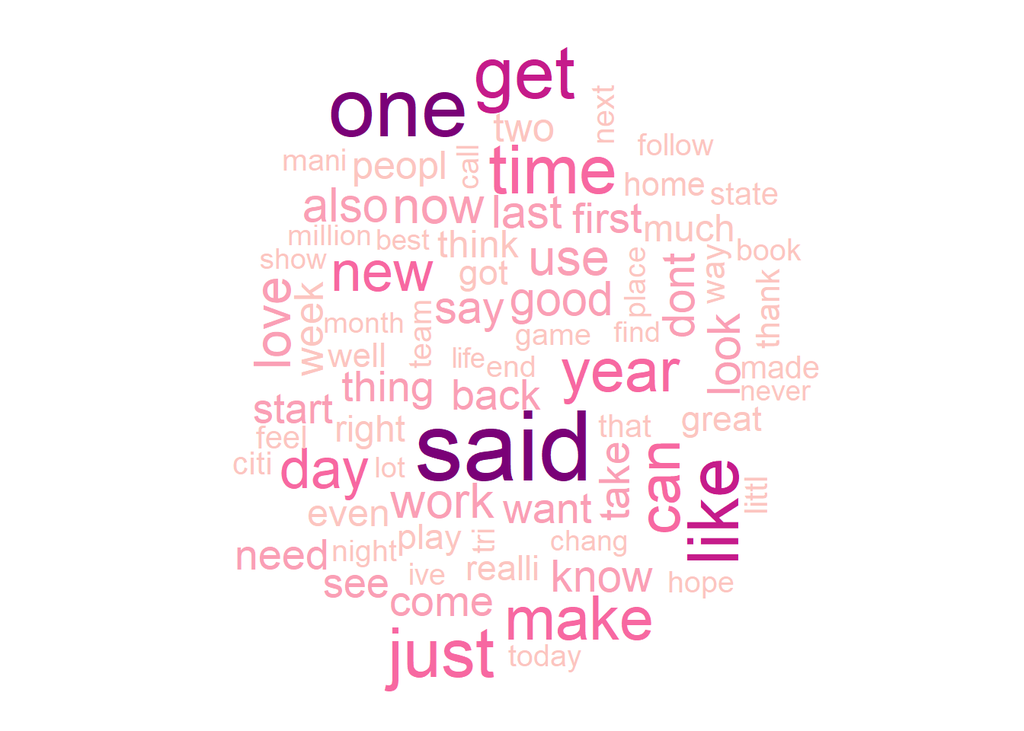

```r
row.names(dfWordFrequency) <-NULL

set.seed(123)

## Word Frequency: Top 75
wordcloud::wordcloud(names(wordFrequency),wordFrequency,
                     max.words=75,colors=brewer.pal(6,"RdPu"))
```

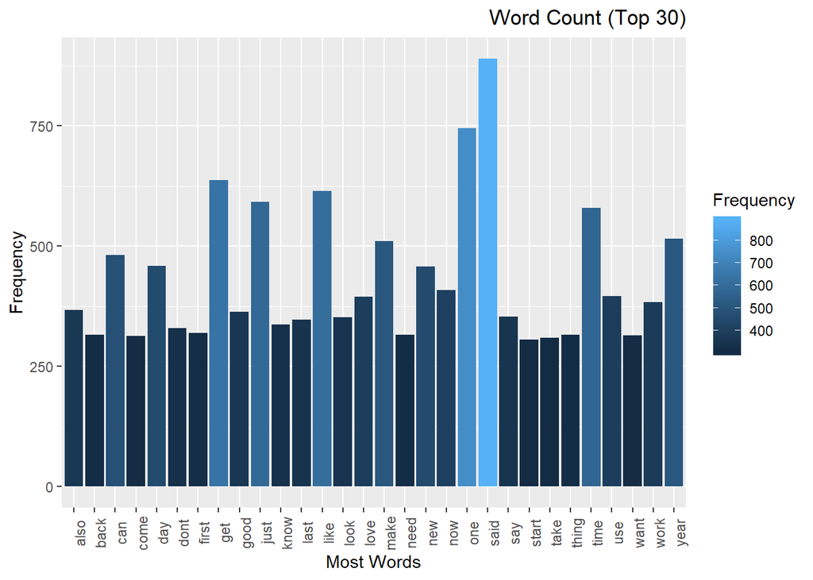

```r
ggWordFrequency <- ggplot(data=dfWordFrequency,aes(x=Words,y=Frequency,fill=Frequency)) + geom_histogram(stat="identity") +
labs(title="Word Count (Top 30)",x="Most Words",y="Frequency")+
theme(axis.text.x=element_text(angle=90)) +
theme(plot.title = element_text(hjust=1))
ggWordFrequency
```

### Next Steps

A Shiny app that takes as input a phrase (multiple words) in a text box input and outputs a prediction of the next word.  
A slide deck consisting of no more than 5 slides created with R Studio Presenter (https://support.rstudio.com/hc/en-us/articles/200486468-Authoring-R-Presentations) pitching your algorithm and app as if you were presenting to your boss or an investor.  
**Data Product**  
Does the link lead to a Shiny app with a text input box that is running on shinyapps.io?  
Does the app load to the point where it can accept input?  
When you type a phrase in the input box do you get a prediction of a single word after pressing submit and/or a suitable delay for the model to compute the answer?  
Put five phrases drawn from Twitter or news articles in English leaving out the last word. Did it give a prediction for every one?  
**Slide Deck**  
Does the link lead to a 5 slide deck on R Pubs?  
Does the slide deck contain a description of the algorithm used to make the prediction?  
Does the slide deck describe the app, give instructions, and describe how it functions?  
How would you describe the experience of using this app?  
Does the app present a novel approach and/or is particularly well done?  
Would you hire this person for your own data science startup company?